# Core Rixpress Functions and Usage

This vignette introduces the core functions required to build a `{rixpress}` pipeline, but doesn’t cover everything yet. It also assumes that you’ve read `vignette("intro-concepts")`. In the next vignette `vignette("tutorial")`, you’ll learn how to set up a complete pipeline from start to finish.

## Getting data into the pipeline

`{rixpress}` provides several functions to help you write derivations. These functions typically start with the prefix `rxp_` and follow a similar structure. The first step in any pipeline is usually to import data. To include data in a `{rixpress}` pipeline, use `rxp_r_file()`:

```r
d0 <- rxp_r_file(
  name = mtcars,
  path = 'data/mtcars.csv',
  read_function = \(x) (read.csv(file = x, sep = "|"))
)
```

`rxp_r_file()`’s `read_function` argument requires an R function with a single argument: the path to the file to be read. In this example, we assume the columns in the `mtcars.csv` file are separated by the `|` symbol. We use an anonymous function to set the correct separator and create a temporary function with a single argument to read the file at `'data/mtcars.csv'`.

Important: This approach means that the `mtcars.csv` file **will be copied** to the `Nix` store. This is essential to how `Nix` works.

Note that `rxp_r_file()` is quite flexible: it works with any function that reads a file, regardless of the file type. The path to the file can also be a URL. See the `vignette("importing-data")` for more details.

## Declaring build steps

Once the data is imported, we can start manipulating it. To generate a derivation similar to the one described in `vignette("intro-concepts")`, but using R and `{dplyr}` instead of `awk`, we would write:

```r
d1 <- rxp_r(
  name = filtered_mtcars,
  expr = dplyr::filter(mtcars, am == 1)
)
```

This syntax should be familiar to users of the `{targets}` package: similar to the `tar_target()` function, you simply provide a name for the derivation and the expression to generate it. That’s all you need to write for `{rixpress}` to generate all the required `Nix` code automatically.

To continue transforming the data, you only need to define a new derivation:

```r
d2 <- rxp_r(
  name = mtcars_mpg,
  expr = dplyr::select(filtered_mtcars, mpg)
)
```

Notice how the name of `d1` (`filtered_mtcars`) is used in `d2`: this is how dependencies between derivations are defined.

## Generating the pipeline

Let’s stop here and generate our pipeline. First, we need to define a list of derivations:

```r
derivs <- list(d0, d1, d2)
```

and pass it to the `rxp_populate()` function:

```r
rxp_populate(derivs)
```

To make the code more concise, you can directly define the list and pass it to `rxp_populate()` using the pipe operator `|>`:

```r
library(rixpress)

list(
  rxp_r_file(
    name = mtcars,
    path = 'data/mtcars.csv',
    read_function = \(x) (read.csv(file = x, sep = "|"))
  ),

  rxp_r(
    name = filtered_mtcars,
    expr = dplyr::filter(mtcars, am == 1)
  ),

  rxp_r(
    name = mtcars_mpg,
    expr = dplyr::select(filtered_mtcars, mpg)
  )
) |>
  rxp_populate()
```

Running `rxp_populate()` performs several actions:

- creates a folder called `_rixpress` in the project’s root directory. This folder contains automatically generated files needed for the pipeline to build successfully.
- generates a file called `pipeline.nix`, which defines the entire pipeline in the `Nix` language.
- if `build = TRUE`, calls `rxp_make()` to build the pipeline.

However, if you try to run the code above, it will likely fail. This is because a crucial piece is missing: the environment in which the pipeline must run!

## Defining a Reproducible Shell for Execution

Remember that the core purpose of using `Nix` is to ensure reproducibility by forcing you to explicitly declare all dependencies. For our pipeline above, we need to specify: Which version of R and which R packages should be used? The pipeline uses `filter()` and `select()` from the `{dplyr}` package, so we must declare these dependencies.

This is where the `{rix}` package comes in. `{rix}` allows you to define reproducible development environments using simple R code. For example, we can define an environment with R and `{dplyr}` like this:

```r
library(rix)

rix(
  date = "2025-04-11",
  r_pkgs = "dplyr",
  ide = "rstudio",
  project_path = ".",
  overwrite = TRUE
)
```

Running this code generates a `default.nix` file that can be built using `Nix` by calling `nix-build`. This creates a development environment containing RStudio, R, and `{dplyr}` as they existed on April 11, 2025. You can use this environment for interactive data analysis just as you would with a standard installation of RStudio, R, and `{dplyr}`. To learn more about `{rix}`, visit https://docs.ropensci.org/rix/.

The reproducible development environments generated by `{rix}` define all the dependencies needed for your pipeline. To use this environment to build a `{rixpress}` pipeline, you must also add `{rixpress}` to the list of packages in the environment. Since `{rixpress}` is still under development, it must be installed from GitHub. Here’s how the complete environment setup script looks:

```r
library(rix)

# Define execution environment
rix(
  date = "2025-04-11",
  r_pkgs = "dplyr",
  git_pkgs = list(
    package_name = "rixpress",
    repo_url = "https://github.com/ropensci/rixpress",
    commit = "HEAD"
  ),
  ide = "rstudio",
  project_path = ".",
  overwrite = TRUE
)
```

In the next vignette, we’ll learn how to use `{rix}` effectively to provide a reproducible execution environment for our pipelines. For now, let’s assume that we’ve used the code above to generate our environment, which we can also use for interactive data analysis.

We can go back to our pipeline to finalise it:

```r
library(rixpress)
# Define pipeline
list(
  rxp_r_file(
    name = mtcars,
    path = 'data/mtcars.csv',
    read_function = \(x) (read.csv(file = x, sep = "|"))
  ),

  rxp_r(
    name = filtered_mtcars,
    expr = dplyr::filter(mtcars, am == 1)
  ),

  rxp_r(
    name = mtcars_mpg,
    expr = dplyr::select(filtered_mtcars, mpg)
  )
) |>
  rxp_populate(project_path = ".")
```

I recommend always using two separate scripts:

- `gen-env.R`: Uses `{rix}` to define the execution environment
- `gen-pipeline.R`: Uses `{rixpress}` to define the reproducible analytical pipeline

You can quickly create these scripts using the `rxp_init()` function, which generates both files with starter code to help you get started quickly.

## Optional steps before building the pipeline

### Graphical representation of the pipeline’s DAG

It’s often helpful to visualise your pipeline as a DAG (directed acyclic graph). By default, the `build` argument of `rxp_populate()` is `FALSE`, so calling this will not build the pipeline:

```r
rxp_populate(derivs)
```

This won’t build the pipeline but will generate useful files, including a JSON representation of the pipeline at `_rixpress/dag.json`. This process is quick and allows you to visualise the graph using `rxp_visnetwork()`, which opens a new tab in your web browser displaying the pipeline’s DAG, generated using the `{visNetwork}` package:

[video not shown]

(This image shows the DAG of a more complex example pipeline.)

For static documents, you can use `rxp_ggdag()` which uses `{ggdag}` under the hood:

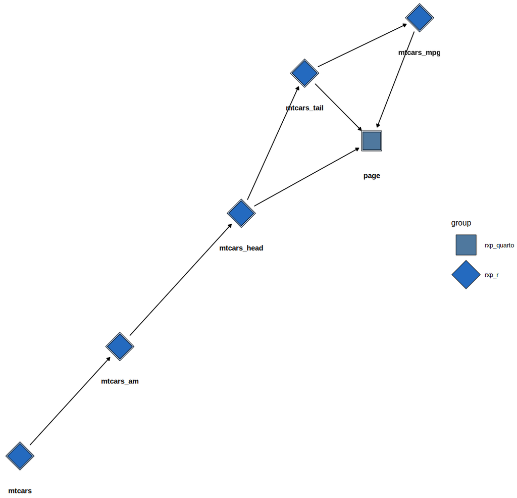

DAG

You can also return the underlying `igraph` object to plot the DAG using other tools:

```r
rxp_dag_for_ci()
```

which saves the `dag.dot` object in the project’s `_rixpress/` folder.

After reviewing the DAG, you can build the pipeline by running `rxp_make()` instead of modifying your original `rxp_populate()` call.

### Tracing the lineage of derivations

It is possible to also trace the lineage of individual derivations using `rxp_trace()`. For example:

```r
rxp_trace("mtcars_mpg")
```

will return:

```r
==== Lineage for: mtcars_mpg ====
Dependencies (ancestors):
  - mtcars_head
    - mtcars_am*
      - mtcars*
  - mtcars_tail
    - mtcars_head*

Reverse dependencies (children):
          - page

Note: '*' marks transitive dependencies (depth >= 2).
```

This makes it quite easy to quickly double check whether derivations were defined correctly. A `*` symbol next to a derivation’s name indicates it is a transitive dependency. Calling `rxp_trace()` without arguments shows the whole graph:

```r
rxp_trace()
```

```r
==== Pipeline dependency tree (outputs → inputs) ====
- page
  - mtcars_head
    - mtcars_am*
      - mtcars*
  - mtcars_tail
    - mtcars_head*
  - mtcars_mpg
    - mtcars_head*
    - mtcars_tail*

Note: '*' marks transitive dependencies (depth >= 2).
```

We are now ready to actually build the artifacts. This is also quite useful for debugging, as detailed in the `vignette("debugging")`.

## Building and inspecting outputs

When you run `gen-pipeline.R` (or execute its contents line-by-line), the environment defined in `default.nix` is used (it’s also possible to define separate environments for different derivations, which we’ll cover in a later vignette).

By default, `rxp_populate()` doesn’t build the pipeline, so to trigger the build, you have to use `rxp_make()`:

```r
rxp_make()
```

You should see something like this:

```r
Build process started...

+ > mtcars building
+ > mtcars_am building
+ > mtcars_head building
+ > mtcars_tail building
+ > mtcars_mpg building
+ > page building
✓ mtcars built
✓ mtcars_am built
✓ mtcars_head built
✓ mtcars_mpg built
✓ mtcars_tail built
✓ page built
✓ pipeline completed [6 completed, 0 errored]
Build successful! Run `rxp_inspect()` for a summary.
Use `rxp_read("derivation_name")` to read objects or
`rxp_load("derivation_name")` to load them into the global environment.
```

Now you can follow these instructions:

1. Use `rxp_inspect()` to see where the outputs are located. This function is particularly useful if the pipeline fails, as it shows which derivations succeeded and which failed, and captures the error messages.
2. Use `rxp_read("mtcars_mpg")` to read the object into your current R session, or `rxp_load("mtcars_mpg")` to load it directly into your global environment.
3. Alternatively, use `rxp_copy("mtcars_mpg")` to create a folder called `pipeline-outputs` containing `mtcars_mpg` as an `.rds` file. If you call `rxp_copy()` without arguments, all pipeline outputs will be copied to this folder.

## No-op builds for individual derivations

You can disable building a specific derivation by setting its `noop_build` parameter to `TRUE`. This creates a no-op build, a placeholder derivation that performs no work:

```r
rxp_r(
  name = turtles,
  expr = occurrence(species, geometry = atlantic),
  noop_build = TRUE
)
```

Any derivations that depend on a no-op build will themselves also resolve to no-op builds. This can be useful when prototyping or debugging a pipeline, allowing you to skip expensive or unnecessary computations while keeping the dependency graph intact. Further details are given in the vignette `vignette("debugging")`.

## Caveats

There are some caveats that you need to be aware of when using `{rixpress}`. Due to how `Nix` works, certain things are simply not possible:

- as mentioned in `vignette("intro-concepts")`, functions are executed in a hermetic sandbox. If they need access to an external resource, the build will fail. For example, if you use a function to get data from an API, you must first retrieve the data in a standard interactive R session, save it to disk, and then include it in the pipeline. The only exception to this is `rxp_r_file()`, which can download a file from a URL;
- if you functions need to access internal resources, use the `additional_files` argument of `rxp_r()` to include these resources into the build sandbox;
- all build artifacts will be saved in the `Nix` store, `/nix/store/`. If you are working with confidential data, make sure no one else can access the `/nix/store` path;
- if you have proprietary R packages, you will need to include them in the `Nix` shell. This is primarily a concern for `{rix}`, as it generates the execution environment. If you need help packaging your proprietary packages, please open an issue on the `{rix}` GitHub repository;
- multi-line expressions aren’t supported; write your derivations as single calls to pure functions.

## Conclusion

Now that you understand the basic, high-level concepts, let’s move on to the next vignette, `vignette("tutorial")`, where we’ll learn how to set up a pipeline from start to finish.